# SH_05_HOSPITAL_NUM

Number of hospital facilities the organization operated · Number report

## Overview

**Description**

Hospital facility number

**Table**

`SH-P05-T00-FAP-COMMUNITY-BENEFIT-POLICY` (one)

**Location code**

`SCHED-H-PART-05-SECTION-A-LINE-00`

**Family**

`SCHED-H-PART-05-SECTION-A-LINE-00`

**Data type**

numeric (xsd: Count2Type)

**Scope**

PC

**Status**

unreviewed

4

xpaths mapped (4 observed)

68,756

filings with a value

2010–2024

tax years observed

3

open flags (1 errors)

## Flags

| Severity | Flag | Xpath | Detail |
| --- | --- | --- | --- |
| ⚠ error | `COLLISION` | IRS990ScheduleH/Form990ScheduleHPartVSectionA/FacilityNumber | 34378 filings contain 2+ of its xpaths; most common set: /Return/ReturnData/IRS990ScheduleH/Form990ScheduleHPartVSectionA/FacilityNumber ; /Return/ReturnData/IRS990ScheduleH/NumberOfHospitalFacilities |
| ▲ warn | `ONE_REPEATS` | IRS990ScheduleH/HospitalFacilitiesGrp/FacilityNum | one-to-one table, repeats in 17.1% of filings (max 43 per filing) |
| ▲ warn | `ONE_REPEATS` | IRS990ScheduleH/Form990ScheduleHPartVSectionA/FacilityNumber | one-to-one table, repeats in 18.7% of filings (max 68 per filing) |

## Xpaths

All mapped xpaths (under /Return/ReturnData or /Return/ReturnHeader), oldest first. Charts label each series by its xpath.

| Xpath | Form | First year | Last year | Versions | Filings | Repeats in |
| --- | --- | --- | --- | --- | --- | --- |
| IRS990ScheduleH/Form990ScheduleHPartVSectionA/FacilityNumber | Sched H | 2010 | 2012 | 12 | 7,404 | 18.7% |
| IRS990ScheduleH/NumberOfHospitalFacilities | Sched H | 2010 | 2012 | 12 | 7,404 | 0.0% |
| IRS990ScheduleH/HospitalFacilitiesCnt | Sched H | 2013 | 2024 | 35 | 26,974 | 0.0% |
| IRS990ScheduleH/HospitalFacilitiesGrp/FacilityNum | Sched H | 2013 | 2024 | 35 | 26,974 | 17.1% |

## Coverage

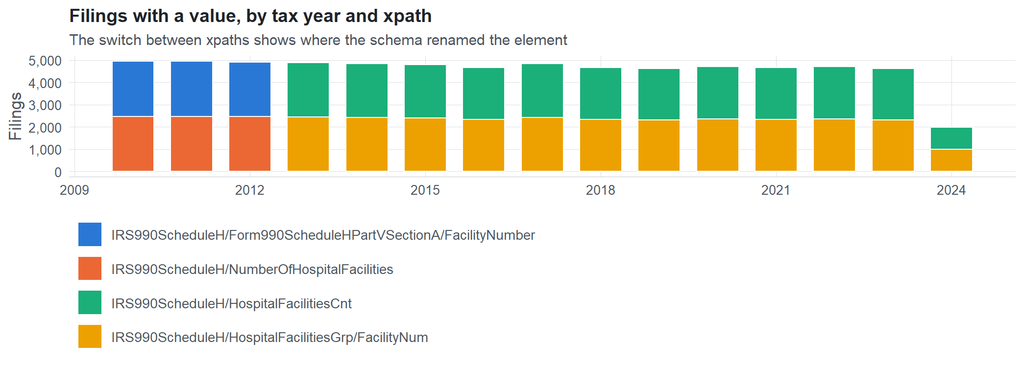

**Table view**

Table view: filings by tax year and series

| Tax year | IRS990ScheduleH/Form990ScheduleHPartVSectionA/FacilityNumber | IRS990ScheduleH/NumberOfHospitalFacilities | IRS990ScheduleH/HospitalFacilitiesCnt | IRS990ScheduleH/HospitalFacilitiesGrp/FacilityNum |
| --- | --- | --- | --- | --- |
| 2010 | 2,475 | 2,475 | 0 | 0 |
| 2011 | 2,475 | 2,475 | 0 | 0 |
| 2012 | 2,454 | 2,454 | 0 | 0 |
| 2013 | 0 | 0 | 2,439 | 2,439 |
| 2014 | 0 | 0 | 2,420 | 2,420 |
| 2015 | 0 | 0 | 2,397 | 2,397 |
| 2016 | 0 | 0 | 2,330 | 2,330 |
| 2017 | 0 | 0 | 2,415 | 2,415 |
| 2018 | 0 | 0 | 2,331 | 2,331 |
| 2019 | 0 | 0 | 2,306 | 2,306 |
| 2020 | 0 | 0 | 2,352 | 2,352 |
| 2021 | 0 | 0 | 2,328 | 2,328 |
| 2022 | 0 | 0 | 2,357 | 2,357 |
| 2023 | 0 | 0 | 2,314 | 2,314 |
| 2024 | 0 | 0 | 985 | 985 |

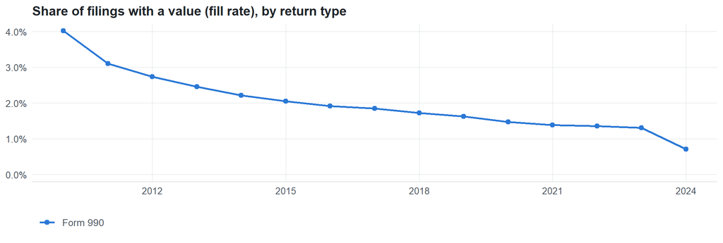

**Table view**

Table view: fill rate

| Tax year | Return type | Filings | All filings | Fill rate |
| --- | --- | --- | --- | --- |
| 2010 | Form 990 | 4,950 | 123,025 | 4.02% |
| 2011 | Form 990 | 4,950 | 159,504 | 3.10% |
| 2012 | Form 990 | 4,908 | 179,688 | 2.73% |
| 2013 | Form 990 | 4,878 | 198,855 | 2.45% |
| 2014 | Form 990 | 4,840 | 218,619 | 2.21% |
| 2015 | Form 990 | 4,794 | 233,519 | 2.05% |
| 2016 | Form 990 | 4,660 | 243,903 | 1.91% |
| 2017 | Form 990 | 4,830 | 261,612 | 1.85% |
| 2018 | Form 990 | 4,662 | 271,442 | 1.72% |
| 2019 | Form 990 | 4,612 | 283,694 | 1.63% |
| 2020 | Form 990 | 4,704 | 320,342 | 1.47% |
| 2021 | Form 990 | 4,656 | 336,480 | 1.38% |
| 2022 | Form 990 | 4,714 | 349,055 | 1.35% |
| 2023 | Form 990 | 4,628 | 354,768 | 1.30% |
| 2024 | Form 990 | 1,970 | 277,298 | 0.71% |

## Repeating groups

Table cardinality in the concordance: **one**. 2 of 4 observed xpaths repeat within a filing.

Repeating element each xpath was observed in (from the raw indexed xpath)

| Xpath | Repeating element | Filings (summed over years) |
| --- | --- | --- |
| IRS990ScheduleH/Form990ScheduleHPartVSectionA/FacilityNumber | (none) | 6017 |
| IRS990ScheduleH/Form990ScheduleHPartVSectionA/FacilityNumber | IRS990ScheduleH/Form990ScheduleHPartVSectionA | 1387 |
| IRS990ScheduleH/NumberOfHospitalFacilities | (none) | 7404 |
| IRS990ScheduleH/HospitalFacilitiesCnt | (none) | 26974 |
| IRS990ScheduleH/HospitalFacilitiesGrp/FacilityNum | (none) | 22357 |
| IRS990ScheduleH/HospitalFacilitiesGrp/FacilityNum | IRS990ScheduleH/HospitalFacilitiesGrp | 4617 |

## Values

| Result | Check | Detail |
| --- | --- | --- |
| ✓ pass | Values parse as numbers | 100.0% of values are numeric |
| ✓ pass | No sudden change in the median between adjacent years | largest change 1.1x (IRS990ScheduleH/Form990ScheduleHPartVSectionA/FacilityNumber, 990, TY2012) |
| ✓ pass | Pooled xpaths are on the same scale (same return type) | largest ratio of medians between xpaths: 1.0x |
| ✓ pass | One scale across xpaths (fraction vs percent) | IRS990ScheduleH/Form990ScheduleHPartVSectionA/FacilityNumber: percent or small count; IRS990ScheduleH/HospitalFacilitiesCnt: percent or small count; IRS990ScheduleH/HospitalFacilitiesGrp/FacilityNum: … |

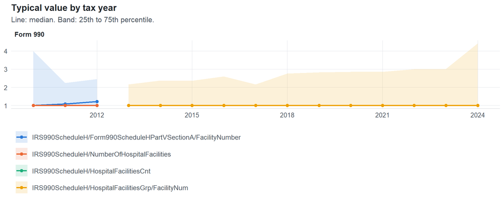

**Table view**

Table view: quartiles by tax year

| Series | Return | Tax year | Filings | P25 | Median | P75 |
| --- | --- | --- | --- | --- | --- | --- |
| IRS990ScheduleH/Form990ScheduleHPartVSectionA/FacilityNumber | 990 | 2010 | 2,475 | 1 | 1 | 4.00 |
| IRS990ScheduleH/Form990ScheduleHPartVSectionA/FacilityNumber | 990 | 2011 | 2,475 | 1 | 1.08 | 2.24 |
| IRS990ScheduleH/Form990ScheduleHPartVSectionA/FacilityNumber | 990 | 2012 | 2,454 | 1.03 | 1.22 | 2.46 |
| IRS990ScheduleH/NumberOfHospitalFacilities | 990 | 2010 | 2,475 | 1 | 1 | 1.00 |
| IRS990ScheduleH/NumberOfHospitalFacilities | 990 | 2011 | 2,475 | 1 | 1 | 1.08 |
| IRS990ScheduleH/NumberOfHospitalFacilities | 990 | 2012 | 2,454 | 1 | 1 | 1.01 |
| IRS990ScheduleH/HospitalFacilitiesCnt | 990 | 2013 | 2,439 | 1 | 1 | 1 |
| IRS990ScheduleH/HospitalFacilitiesCnt | 990 | 2014 | 2,420 | 1 | 1 | 1 |
| IRS990ScheduleH/HospitalFacilitiesCnt | 990 | 2015 | 2,397 | 1 | 1 | 1 |
| IRS990ScheduleH/HospitalFacilitiesCnt | 990 | 2016 | 2,330 | 1 | 1 | 1 |
| IRS990ScheduleH/HospitalFacilitiesCnt | 990 | 2017 | 2,415 | 1 | 1 | 1 |
| IRS990ScheduleH/HospitalFacilitiesCnt | 990 | 2018 | 2,331 | 1 | 1 | 1 |
| IRS990ScheduleH/HospitalFacilitiesCnt | 990 | 2019 | 2,306 | 1 | 1 | 1 |
| IRS990ScheduleH/HospitalFacilitiesCnt | 990 | 2020 | 2,352 | 1 | 1 | 1 |
| IRS990ScheduleH/HospitalFacilitiesCnt | 990 | 2021 | 2,328 | 1 | 1 | 1 |
| IRS990ScheduleH/HospitalFacilitiesCnt | 990 | 2022 | 2,357 | 1 | 1 | 1 |
| IRS990ScheduleH/HospitalFacilitiesCnt | 990 | 2023 | 2,314 | 1 | 1 | 1 |
| IRS990ScheduleH/HospitalFacilitiesCnt | 990 | 2024 | 985 | 1 | 1 | 1 |
| IRS990ScheduleH/HospitalFacilitiesGrp/FacilityNum | 990 | 2013 | 2,439 | 1 | 1 | 2.16 |
| IRS990ScheduleH/HospitalFacilitiesGrp/FacilityNum | 990 | 2014 | 2,420 | 1 | 1 | 2.37 |
| IRS990ScheduleH/HospitalFacilitiesGrp/FacilityNum | 990 | 2015 | 2,397 | 1 | 1 | 2.36 |
| IRS990ScheduleH/HospitalFacilitiesGrp/FacilityNum | 990 | 2016 | 2,330 | 1 | 1 | 2.60 |
| IRS990ScheduleH/HospitalFacilitiesGrp/FacilityNum | 990 | 2017 | 2,415 | 1 | 1 | 2.16 |
| IRS990ScheduleH/HospitalFacilitiesGrp/FacilityNum | 990 | 2018 | 2,331 | 1 | 1 | 2.76 |
| IRS990ScheduleH/HospitalFacilitiesGrp/FacilityNum | 990 | 2019 | 2,306 | 1 | 1 | 2.83 |
| IRS990ScheduleH/HospitalFacilitiesGrp/FacilityNum | 990 | 2020 | 2,352 | 1 | 1 | 2.85 |
| IRS990ScheduleH/HospitalFacilitiesGrp/FacilityNum | 990 | 2021 | 2,328 | 1 | 1 | 2.85 |
| IRS990ScheduleH/HospitalFacilitiesGrp/FacilityNum | 990 | 2022 | 2,357 | 1 | 1 | 3.00 |
| IRS990ScheduleH/HospitalFacilitiesGrp/FacilityNum | 990 | 2023 | 2,314 | 1 | 1 | 3.01 |
| IRS990ScheduleH/HospitalFacilitiesGrp/FacilityNum | 990 | 2024 | 985 | 1 | 1 | 4.42 |

Summary by xpath and return type (all years)

| Series | Return | Filings | % numeric | % zero | % negative | Median (typical year) | P99 (typical year) |
| --- | --- | --- | --- | --- | --- | --- | --- |
| IRS990ScheduleH/Form990ScheduleHPartVSectionA/FacilityNumber | 990 | 7,404 | 100 | 1.86 | 0 | 1 | 35 |
| IRS990ScheduleH/NumberOfHospitalFacilities | 990 | 7,404 | 100 | 0.11 | 0 | 1 | 12 |
| IRS990ScheduleH/HospitalFacilitiesCnt | 990 | 26,974 | 100 | 0.04 | 0 | 1 | 10 |
| IRS990ScheduleH/HospitalFacilitiesGrp/FacilityNum | 990 | 26,974 | 100 | 0.01 | 0 | 1 | 20 |

Scale of each xpath

| Series | P99 (typical year) | Implied scale |
| --- | --- | --- |
| IRS990ScheduleH/Form990ScheduleHPartVSectionA/FacilityNumber | 35 | percent or small count |
| IRS990ScheduleH/HospitalFacilitiesCnt | 10 | percent or small count |
| IRS990ScheduleH/HospitalFacilitiesGrp/FacilityNum | 20 | percent or small count |
| IRS990ScheduleH/NumberOfHospitalFacilities | 12 | percent or small count |

## Examples

| Tax year | Return | Xpath | Organization | Value | Source |
| --- | --- | --- | --- | --- | --- |
| 2024 | 990 | IRS990ScheduleH/HospitalFacilitiesCnt | UNION HOSPITAL INC | 2 | [XML](https://gt990datalake-rawdata.s3.amazonaws.com/EfileData/XmlFiles/202503219349303730_public.xml) |
| 2024 | 990 | IRS990ScheduleH/HospitalFacilitiesGrp/FacilityNum | THE CLEVELAND CLINIC FOUNDATION | 1 | [XML](https://gt990datalake-rawdata.s3.amazonaws.com/EfileData/XmlFiles/202513189349302136_public.xml) |
| 2023 | 990 | IRS990ScheduleH/HospitalFacilitiesCnt | ARH TUG VALLEY HEALTH SERVICES INC | 2 | [XML](https://gt990datalake-rawdata.s3.amazonaws.com/EfileData/XmlFiles/202511349349306946_public.xml) |
| 2023 | 990 | IRS990ScheduleH/HospitalFacilitiesGrp/FacilityNum | Clay County Medical Corporation | 1 | [XML](https://gt990datalake-rawdata.s3.amazonaws.com/EfileData/XmlFiles/202502279349303290_public.xml) |
| 2022 | 990 | IRS990ScheduleH/HospitalFacilitiesCnt | MADELIA HEALTH | 1 | [XML](https://gt990datalake-rawdata.s3.amazonaws.com/EfileData/XmlFiles/202402909349301315_public.xml) |
| 2022 | 990 | IRS990ScheduleH/HospitalFacilitiesGrp/FacilityNum | MADELIA HEALTH | 1 | [XML](https://gt990datalake-rawdata.s3.amazonaws.com/EfileData/XmlFiles/202402909349301315_public.xml) |
| 2021 | 990 | IRS990ScheduleH/HospitalFacilitiesCnt | TRI-COUNTY MEMORIAL HOSPITAL INC | 1 | [XML](https://gt990datalake-rawdata.s3.amazonaws.com/EfileData/XmlFiles/202243199349308309_public.xml) |
| 2021 | 990 | IRS990ScheduleH/HospitalFacilitiesGrp/FacilityNum | TRI-COUNTY MEMORIAL HOSPITAL INC | 1 | [XML](https://gt990datalake-rawdata.s3.amazonaws.com/EfileData/XmlFiles/202243199349308309_public.xml) |
| 2020 | 990 | IRS990ScheduleH/HospitalFacilitiesCnt | Memorial Hospital Association | 1 | [XML](https://gt990datalake-rawdata.s3.amazonaws.com/EfileData/XmlFiles/202133139349303608_public.xml) |
| 2020 | 990 | IRS990ScheduleH/HospitalFacilitiesGrp/FacilityNum | Memorial Hospital Association | 1 | [XML](https://gt990datalake-rawdata.s3.amazonaws.com/EfileData/XmlFiles/202133139349303608_public.xml) |
| 2019 | 990 | IRS990ScheduleH/HospitalFacilitiesCnt | CEDARS-SINAI MEDICAL CENTER | 1 | [XML](https://gt990datalake-rawdata.s3.amazonaws.com/EfileData/XmlFiles/202131349349305998_public.xml) |
| 2019 | 990 | IRS990ScheduleH/HospitalFacilitiesGrp/FacilityNum | CEDARS-SINAI MEDICAL CENTER | 1 | [XML](https://gt990datalake-rawdata.s3.amazonaws.com/EfileData/XmlFiles/202131349349305998_public.xml) |

## Reviewer checklist

- The definition matches the form line and instructions for every xpath’s schema years.
- Every xpath pooled here measures the same thing on the 990 and 990-EZ (close enough for analysis).
- The coverage chart has no unexplained gaps or jumps between tax years.
- Each open flag is fixed, or accepted with a note in validation_log.csv.
- Counts are whole numbers and plausible (e.g. employees, volunteers, voting members).
- Ratios and percentages use one scale (0-1 or 0-100) across all xpaths and years.
- Units match the form line (hours per week, number of states, percent of support).

Record the review as a row in `inst/extdata/src/validation_log.csv` (variable_name, reviewer, date, status, note). Evidence built 2026-09-23 17:09:04 MST from the ef2 DuckDB builds (tax years 2009–2024).